# Lecture/Lab on Robust Data Analyses

Susan Holmes

7/29/2019

# Robust, nonparametric methods

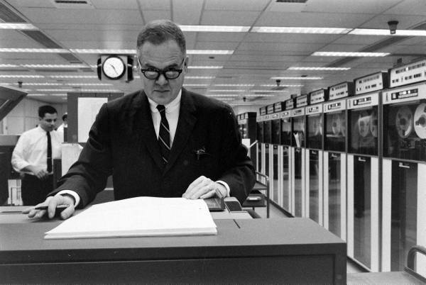

John Tukey

John Tukey was an applied statistician who invented **Exploratory Data Analysis**.  
He also defined and studied the notion of Robustness.

## An Example: Kostic study of colorectal carcinoma

Genomic analysis identifies association of Fusobacterium with colorectal carcinoma. Kostic, A. D., Gevers, D., Pedamallu, C. S., Michaud, M., Duke, F., Earl, A. M., et al. (2012). Genome research, 22(2), 292-298.

```r
library(phyloseq)
filepath = system.file("extdata", "study_1457_split_library_seqs_and_mapping.zip", package="phyloseq")
kostic = microbio_me_qiime(filepath)
```

```
## Found biom-format file, now parsing it...
## Done parsing biom...
## Importing Sample Metdadata from mapping file...
## Merging the imported objects...
## Successfully merged, phyloseq-class created.
##  Returning...
```

```r
kostic
```

```
## phyloseq-class experiment-level object
## otu_table()   OTU Table:         [ 2505 taxa and 190 samples ]
## sample_data() Sample Data:       [ 190 samples by 71 sample variables ]
## tax_table()   Taxonomy Table:    [ 2505 taxa by 7 taxonomic ranks ]
```

```r
head(sample_data(kostic)$DIAGNOSIS, 10)
```

```
##  [1] Healthy Tumor   Tumor   Healthy Healthy Healthy Tumor   Healthy Healthy
## [10] Healthy
## Levels: Healthy None Tumor
```

### A little preprocessing

Tabulate the levels of the `DIAGNOSIS` variable:

```r
table(sample_data(kostic)$DIAGNOSIS)
```

```
##
## Healthy    None   Tumor
##      95       5      90
```

We want to remove the 5 samples that had no DIAGNOSIS attribute assigned.

These introduce a spurious third design class that is actually a rare artifact in the dataset.

```r
kostic <- subset_samples(kostic, DIAGNOSIS != "None")
```

Let’s explore the sample depths first and make a few exploratory plots of their variation:

```r
sample_sums(kostic)
```

```
##  C0333.N.518126  C0333.T.518046 38U4VAHB.518100 XZ33PN7O.518030
##            5651            1286            6546            4572
## GQ6LSNI6.518106  C0270.N.518041 HZIMMAM6.518095 LRQ9WN6C.518048
##            8714            8018            9327            5833
## A8A34NCW.518023  C0332.N.518027    C10.S.517995 MQE9ONGV.518038
##            6971            1833            4536            2666
##  C0230.N.517992  C0256.N.518170 HZIMMNL5.518062 GQ6LSABJ.518010
##            1018            8641            6394            6250
##  C0282.N.518138 TV28INUO.518004  C0315.N.518021  C0235.N.517993
##            1672            4250            7439            1513
## 5TA9VN6K.518161 A8A34AP9.518086 UEL2GAPI.518173 O436FAO8.518097
##            8934            7214            8341            7389
##  C0378.N.518158 41E1KNBP.517985  C0378.T.518104 R8J9ZNOW.518040
##            7613            4798            9584            7524
## 8XBKGABK.517998 R8J9ZAGC.518059 5TA9VAT9.518088 OTGGZAZO.518108
##             294           10973            6269            7846
##  C0269.N.518130  C0271.T.518078  C0318.N.518105  C0159.T.518087
##            7771            1872            5341            4311
##  C0318.T.518140 O436FNP3.518007  C0209.N.517984  C0240.N.518020
##            7853            1041            5664            6017
##  C0306.N.518003 MQETMNL4.518037  C0209.T.518128  C0112.T.518024
##            6253            4103            3075             617
##  C0355.T.518157  C0322.N.518165 6G2KBNS6.518045  C0240.T.518052
##            3874            2410            6963            3952
##  C0268.T.518114  C0285.T.518044 41E1KAMA.517991 QFHRSAG2.518005
##            1388            4169            7016            5150
## I7ROLN9P.518079 QFHRSNIH.518116  C0271.N.518022 KIXFRARY.518160
##            5630            6937            6316            5692
##  C0133.N.518051  C0268.N.518089 OTGGZN5Y.518063  C0134.N.518072
##            3594            2778            5324            5903
##  C0395.N.518054 UZ65XAS5.518119  C0311.T.518131 5EKFOAO4.518164
##            3874            7817            8921            5864
##  C0294.T.518134  C0388.N.518136  C0186.N.518143 38U4VNBW.518090
##            2594            7084            3523            4320
##  C0334.T.518147 JIDZEN4J.518073 JIDZEAPD.518149 LRQ9WAHA.518036
##            4759            3016            6192            3868
## UZ65XN27.518028  C0159.N.518042  C0306.T.518122  C0394.N.518031
##            6081            5583            1451            3371
##  C0342.N.518068 82S3MAZ4.518145     C4.T.518118  C0398.N.518152
##            8459            6000            5191            4906
```

[output cut: 39 more lines]

```
##             524            9734            2285            3206
## KIXFRNL2.518129  C0374.T.518127  C0275.N.518076 59S9WAIH.518013
##            6973             926            5875            3420
##  C0314.T.518025 6G2KBASQ.517999  C0133.T.518133 UEL2GN92.518058
##            3099            3098            2694            4917
## 59S9WNC6.518055  C0235.T.518049  C0362.T.518026 TV28IANZ.518070
##            4724            4566            4063            2606
##    C10.T.518056  C0275.T.518032     C3.S.517996 MQE9OAS7.518008
##             812            6317              73            4263
## 32I9UAPQ.518112  C0398.T.518092 UTWNWANU.518168 UTWNWN3P.518012
##            7359             238            6669            7122
## BFJMKAKB.518159 XBS5MA8H.517990     C3.T.517994 32I9UNA9.518098
##            2283             380              55            3207
## BFJMKNMP.518102
##             466
```

```r
summary(sample_sums(kostic))
```

```
##    Min. 1st Qu.  Median    Mean 3rd Qu.    Max.
##      46    2374    4507    4532    6317   11187
```

We want to remove samples with less than 500 reads (counts). Note that this kind of data cleanup is useful, necessary, and should be well-documented because it can also be dangerous to alter or omit data without clear documentation.

```r
kostic <- prune_samples(sample_sums(kostic) > 500, kostic)
kostic
```

```
## phyloseq-class experiment-level object
## otu_table()   OTU Table:         [ 2505 taxa and 177 samples ]
## sample_data() Sample Data:       [ 177 samples by 71 sample variables ]
## tax_table()   Taxonomy Table:    [ 2505 taxa by 7 taxonomic ranks ]
```

```r
sample_sums(kostic)
```

```
##  C0333.N.518126  C0333.T.518046 38U4VAHB.518100 XZ33PN7O.518030
##            5651            1286            6546            4572
## GQ6LSNI6.518106  C0270.N.518041 HZIMMAM6.518095 LRQ9WN6C.518048
##            8714            8018            9327            5833
## A8A34NCW.518023  C0332.N.518027    C10.S.517995 MQE9ONGV.518038
##            6971            1833            4536            2666
##  C0230.N.517992  C0256.N.518170 HZIMMNL5.518062 GQ6LSABJ.518010
##            1018            8641            6394            6250
##  C0282.N.518138 TV28INUO.518004  C0315.N.518021  C0235.N.517993
##            1672            4250            7439            1513
## 5TA9VN6K.518161 A8A34AP9.518086 UEL2GAPI.518173 O436FAO8.518097
##            8934            7214            8341            7389
##  C0378.N.518158 41E1KNBP.517985  C0378.T.518104 R8J9ZNOW.518040
##            7613            4798            9584            7524
## R8J9ZAGC.518059 5TA9VAT9.518088 OTGGZAZO.518108  C0269.N.518130
##           10973            6269            7846            7771
##  C0271.T.518078  C0318.N.518105  C0159.T.518087  C0318.T.518140
##            1872            5341            4311            7853
## O436FNP3.518007  C0209.N.517984  C0240.N.518020  C0306.N.518003
##            1041            5664            6017            6253
## MQETMNL4.518037  C0209.T.518128  C0112.T.518024  C0355.T.518157
##            4103            3075             617            3874
##  C0322.N.518165 6G2KBNS6.518045  C0240.T.518052  C0268.T.518114
##            2410            6963            3952            1388
##  C0285.T.518044 41E1KAMA.517991 QFHRSAG2.518005 I7ROLN9P.518079
##            4169            7016            5150            5630
## QFHRSNIH.518116  C0271.N.518022 KIXFRARY.518160  C0133.N.518051
##            6937            6316            5692            3594
##  C0268.N.518089 OTGGZN5Y.518063  C0134.N.518072  C0395.N.518054
##            2778            5324            5903            3874
## UZ65XAS5.518119  C0311.T.518131 5EKFOAO4.518164  C0294.T.518134
##            7817            8921            5864            2594
##  C0388.N.518136  C0186.N.518143 38U4VNBW.518090  C0334.T.518147
##            7084            3523            4320            4759
## JIDZEN4J.518073 JIDZEAPD.518149 LRQ9WAHA.518036 UZ65XN27.518028
##            3016            6192            3868            6081
##  C0159.N.518042  C0306.T.518122  C0394.N.518031  C0342.N.518068
##            5583            1451            3371            8459
## 82S3MAZ4.518145     C4.T.518118  C0398.N.518152  C0388.T.518015
##            6000            5191            4906            3504
```

[output cut: 35 more lines]

```
##            2074            2642            4233            5628
##  C0325.T.518083  C0212.T.518155  C0399.N.518011  C0334.N.518066
##            4722             524            9734            2285
## XZ33PA3O.518135 KIXFRNL2.518129  C0374.T.518127  C0275.N.518076
##            3206            6973             926            5875
## 59S9WAIH.518013  C0314.T.518025 6G2KBASQ.517999  C0133.T.518133
##            3420            3099            3098            2694
## UEL2GN92.518058 59S9WNC6.518055  C0235.T.518049  C0362.T.518026
##            4917            4724            4566            4063
## TV28IANZ.518070    C10.T.518056  C0275.T.518032 MQE9OAS7.518008
##            2606             812            6317            4263
## 32I9UAPQ.518112 UTWNWANU.518168 UTWNWN3P.518012 BFJMKAKB.518159
##            7359            6669            7122            2283
## 32I9UNA9.518098
##            3207
```

```r
summary(sample_sums(kostic))
```

```
##    Min. 1st Qu.  Median    Mean 3rd Qu.    Max.
##     524    2606    4722    4726    6430   11187
```

### A tidy trick (using the pipe operator `%>%`)

```r
library(dplyr)
sample_sums(kostic) %>% summary()
```

```
##    Min. 1st Qu.  Median    Mean 3rd Qu.    Max.
##     524    2606    4722    4726    6430   11187
```

### How many nonzero elements in the matrix ?

```r
sum(otu_table(kostic)>0)
```

```
## [1] 34776
```

### How many cells have more than 3 reads in the matrix ?

```r
sum(otu_table(kostic)>3)
```

```
## [1] 14773
```

### How to make a presence / absence matrix such that presence is defined as at least 2 reads?

```r
PA = data.frame(otu_table(kostic))
PA[PA<2] = 0
PA[PA>1] = 1
apply(PA,2,sum)
```

```
##   C0333.N.518126   C0333.T.518046 X38U4VAHB.518100  XZ33PN7O.518030
##              130               97              143              117
##  GQ6LSNI6.518106   C0270.N.518041  HZIMMAM6.518095  LRQ9WN6C.518048
##              201              180              149              131
##  A8A34NCW.518023   C0332.N.518027     C10.S.517995  MQE9ONGV.518038
##              125              132              145               84
##   C0230.N.517992   C0256.N.518170  HZIMMNL5.518062  GQ6LSABJ.518010
##              119              144              133              165
##   C0282.N.518138  TV28INUO.518004   C0315.N.518021   C0235.N.517993
##              148               91              133               88
## X5TA9VN6K.518161  A8A34AP9.518086  UEL2GAPI.518173  O436FAO8.518097
##              148              121              147               31
##   C0378.N.518158 X41E1KNBP.517985   C0378.T.518104  R8J9ZNOW.518040
##              271               96              141              119
##  R8J9ZAGC.518059 X5TA9VAT9.518088  OTGGZAZO.518108   C0269.N.518130
##              117              113              126              235
##   C0271.T.518078   C0318.N.518105   C0159.T.518087   C0318.T.518140
##              163              187              109               95
##  O436FNP3.518007   C0209.N.517984   C0240.N.518020   C0306.N.518003
##               41              106              185              171
##  MQETMNL4.518037   C0209.T.518128   C0112.T.518024   C0355.T.518157
##              115               97               65              118
##   C0322.N.518165 X6G2KBNS6.518045   C0240.T.518052   C0268.T.518114
##              142              189              166               92
##   C0285.T.518044 X41E1KAMA.517991  QFHRSAG2.518005  I7ROLN9P.518079
##              121               77              165               78
##  QFHRSNIH.518116   C0271.N.518022  KIXFRARY.518160   C0133.N.518051
##              186              257              254              144
##   C0268.N.518089  OTGGZN5Y.518063   C0134.N.518072   C0395.N.518054
##              175              185              227              138
##  UZ65XAS5.518119   C0311.T.518131 X5EKFOAO4.518164   C0294.T.518134
##              156              115              137              137
##   C0388.N.518136   C0186.N.518143 X38U4VNBW.518090   C0334.T.518147
##              182              143              115              143
##  JIDZEN4J.518073  JIDZEAPD.518149  LRQ9WAHA.518036  UZ65XN27.518028
##              164              159              211              236
##   C0159.N.518042   C0306.T.518122   C0394.N.518031   C0342.N.518068
##              146               91              144              244
## X82S3MAZ4.518145      C4.T.518118   C0398.N.518152   C0388.T.518015
##              118              125              173              141
```

[output cut: 35 more lines]

```
##               61              106               60              249
##   C0325.T.518083   C0212.T.518155   C0399.N.518011   C0334.N.518066
##              110               75              207              141
##  XZ33PA3O.518135  KIXFRNL2.518129   C0374.T.518127   C0275.N.518076
##               78               97               81              123
## X59S9WAIH.518013   C0314.T.518025 X6G2KBASQ.517999   C0133.T.518133
##               92               36              159               73
##  UEL2GN92.518058 X59S9WNC6.518055   C0235.T.518049   C0362.T.518026
##              116               84               45               50
##  TV28IANZ.518070     C10.T.518056   C0275.T.518032  MQE9OAS7.518008
##               79               57               66               51
## X32I9UAPQ.518112  UTWNWANU.518168  UTWNWN3P.518012  BFJMKAKB.518159
##               55               55               42               31
## X32I9UNA9.518098
##               58
```

```r
apply(PA,2,sum) %>% summary()
```

```
##    Min. 1st Qu.  Median    Mean 3rd Qu.    Max.
##    25.0    89.0   125.0   126.7   155.0   271.0
```

If we actually want to have a phyloseq object and have a new otu_table with only presence absence, we do the following.

```r
kMat <- kostic %>% otu_table %>% as("matrix")
PA <- ifelse(kMat > 1, 1, 0) %>% otu_table(taxa_are_rows = TRUE)
```

# Robust methods

[Wikipedia entry](https://en.wikipedia.org/wiki/Robust_statistics)

## Use rankings instead of values.

What is the highest ranking in the following vector?

```r
tt = sample(100,19)
tt
```

```
##  [1] 77 47 91 27 20 79 18 99 83 76 52 84 42 28 39 26 34 54 59
```

```r
rank(tt)
```

```
##  [1] 14  9 18  4  2 15  1 19 16 13 10 17  8  5  7  3  6 11 12
```

We can replace the most abundant by a ranking score where a high ranking corresponds to an abundant taxon.

```r
abund <- otu_table(kostic)
abund[1:5,1:8]
```

```
## OTU Table:          [5 taxa and 8 samples]
##                      taxa are rows
##        C0333.N.518126 C0333.T.518046 38U4VAHB.518100 XZ33PN7O.518030
## 304309             40              4               1               2
## 469478              0              0               0               0
## 208196              0              0               0               0
## 358030              0              0               0               0
## 16076             271             28             110               7
##        GQ6LSNI6.518106 C0270.N.518041 HZIMMAM6.518095 LRQ9WN6C.518048
## 304309              30              1               4               8
## 469478               0              0               0               0
## 208196               0              0               0               0
## 358030               0              0               0               0
## 16076               34              0               0               0
```

```r
abund_ranks <- apply(abund, 2, rank)
abund_ranks[1:5,1:8]
```

```
##        C0333.N.518126 C0333.T.518046 38U4VAHB.518100 XZ33PN7O.518030
## 304309         2477.0         2452.0            2326          2398.5
## 469478         1146.5         1183.5            1145          1164.5
## 208196         1146.5         1183.5            1145          1164.5
## 358030         1146.5         1183.5            1145          1164.5
## 16076          2499.0         2494.0            2482          2444.5
##        GQ6LSNI6.518106 C0270.N.518041 HZIMMAM6.518095 LRQ9WN6C.518048
## 304309          2459.5         2272.5          2408.5            2449
## 469478          1093.5         1110.0          1134.5            1155
## 208196          1093.5         1110.0          1134.5            1155
## 358030          1093.5         1110.0          1134.5            1155
## 16076           2467.0         1110.0          1134.5            1155
```

```r
abund_ranks <-abund_ranks - 2000
abund_ranks[abund_ranks < 1] <- 1
abund_ranks[1:5,1:8]
```

```
##        C0333.N.518126 C0333.T.518046 38U4VAHB.518100 XZ33PN7O.518030
## 304309            477            452             326           398.5
## 469478              1              1               1             1.0
## 208196              1              1               1             1.0
## 358030              1              1               1             1.0
## 16076             499            494             482           444.5
##        GQ6LSNI6.518106 C0270.N.518041 HZIMMAM6.518095 LRQ9WN6C.518048
## 304309           459.5          272.5           408.5             449
## 469478             1.0            1.0             1.0               1
## 208196             1.0            1.0             1.0               1
## 358030             1.0            1.0             1.0               1
## 16076            467.0            1.0             1.0               1
```

Plug the rankings to replace the original abundances in the phyloseq object:

```r
kostica <-kostic
otu_table(kostica) <- otu_table(abund_ranks,taxa_are_rows=TRUE)
```

## Perform a simple Wilcox test on some of the taxa-rows

```r
tab2 <- abund_ranks[c(2008,2315,1886, 733, 816, 1481),]
diagnosis=as.factor(sample_data(kostic)$DIAGNOSIS)
```

```r
x <- tab2[1,]
wilcox.test(x ~ diagnosis,
            alternative ="two.sided")
```

```
##
##  Wilcoxon rank sum test with continuity correction
##
## data:  x by diagnosis
## W = 2625.5, p-value = 0.0001506
## alternative hypothesis: true location shift is not equal to 0
```

```r
wilcox.test(tab2[4,] ~ diagnosis,
            alternative ="two.sided")
```

```
##
##  Wilcoxon rank sum test with continuity correction
##
## data:  tab2[4, ] by diagnosis
## W = 3956, p-value = 0.3366
## alternative hypothesis: true location shift is not equal to 0
```

Multiple testing correction can be done using the `multtest` Bioconductor package:

```r
if (!requireNamespace("BiocManager", quietly = TRUE))
    install.packages("BiocManager")

BiocManager::install("multtest")
```

For a tutorial showing how to use a more refined normalisation of this data set, see the [DESeq2 example here](https://joey711.github.io/phyloseq-extensions/DESeq2.html)